# Forest Plot: Treatment x Biomarker Interaction Hazard Ratios

METIMMOX-1 Economic Evaluation

Author

Ben Geisler

Published

June 19, 2026

This vignette consolidates the treatment-by-biomarker interaction hazard ratios from the clinical effectiveness analysis into a single forest plot. It reports the `CRP x Tx` and `TMB/BRAF x Tx` interactions from the **unified pre-treatment-biomarker model** and the `TLR x Tx` interaction from the **week-9 landmark** TLR model, each estimated by both **Firth-corrected Cox** regression and **ridge Cox** regression. Model formulas and extraction logic mirror `scripts/QMD/report/clinical_effectiveness.qmd`.

## Forest Plot

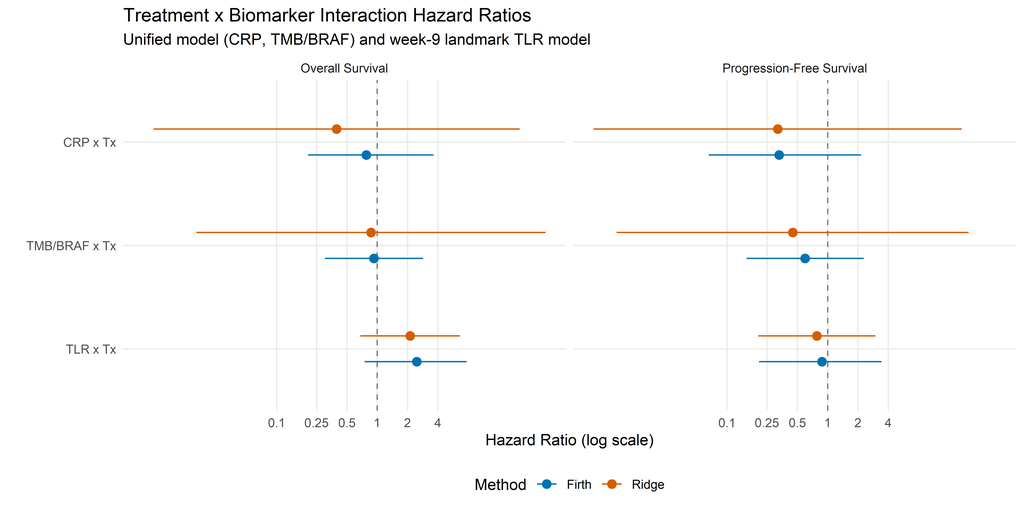

**Interpretation:** HR < 1 indicates that biomarker-positive patients derive greater benefit from experimental treatment (reduced hazard of death/progression). The dashed line at HR = 1 represents no differential treatment effect.

**Methods note:** Firth confidence intervals are profile-likelihood intervals (from `coxphf`); ridge confidence intervals are Wald intervals computed on the log scale as `exp(log(HR) +/- 1.96 x SE)`, since the ridge fit does not return profile-likelihood intervals. The unified model penalizes (ridge) the CRP and TMB/BRAF main effects, leaving the interaction terms unpenalized; the landmark TLR model penalizes the TLR main effect and the TLR x Tx interaction, leaving the adjustment covariates unpenalized.